2018-05-09

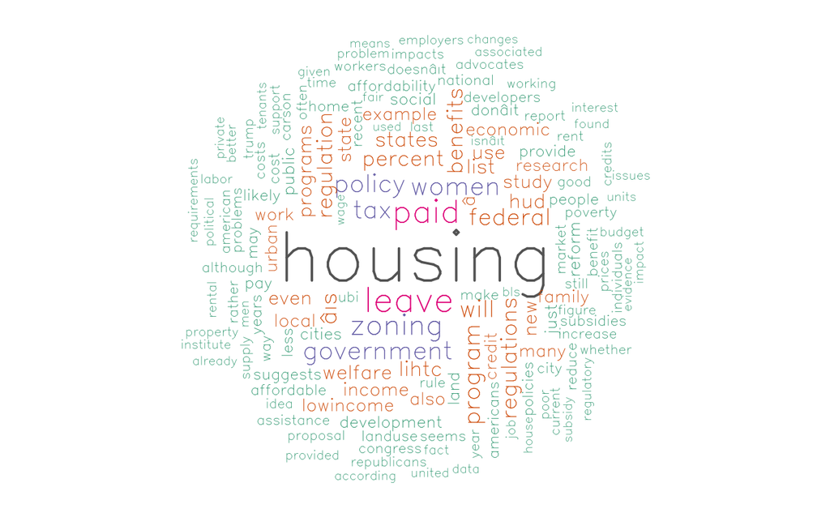

This is Vanessa Brown Calder’s web analytics report from between the dates 2016-07-21 and 2018-05-06.

Below is a count of content published by Vanessa Brown Calder that has been colored according to co-authorship.

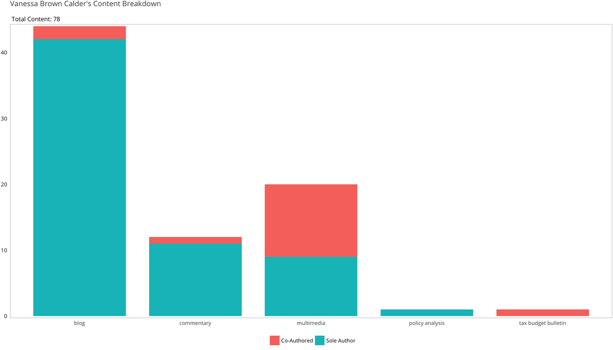

**Total unique viewers with 10 top content on that** colored by topic between the dates 2016-07-21 and 2018-05-06.

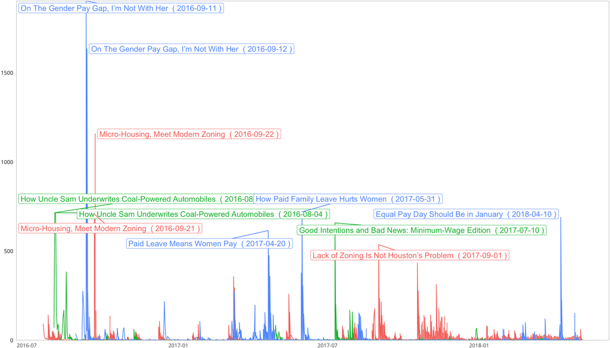

**Popular Co-Authors for Vanessa Brown Calder**

Note: multimedia is ommitted.

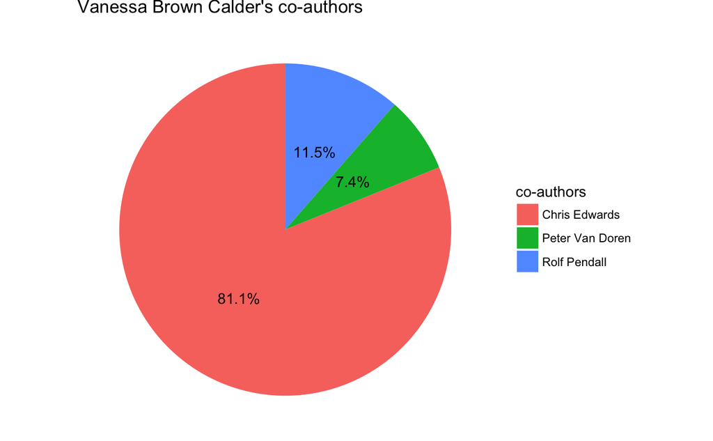

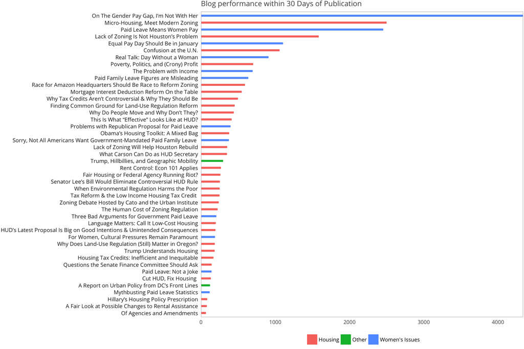

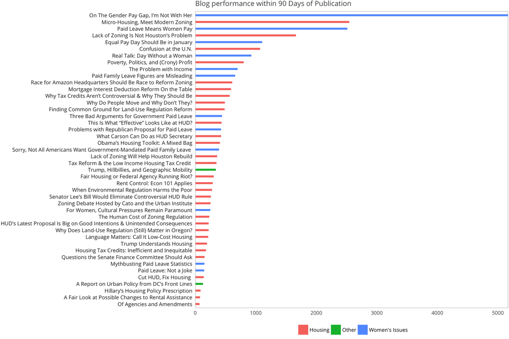

This section examines time spent on reading an article relative to the number of words of text in the article. Below are the 10 best and worst performing articles. Multimedia (e.g. Podcasts) are ignored. This measure is designed to give you a rough idea of the types of articles people are likely to read through.

**Note:** This measure has some methodological issues related to sample size that need to be addressed and thus should be treated solely as an illustration.

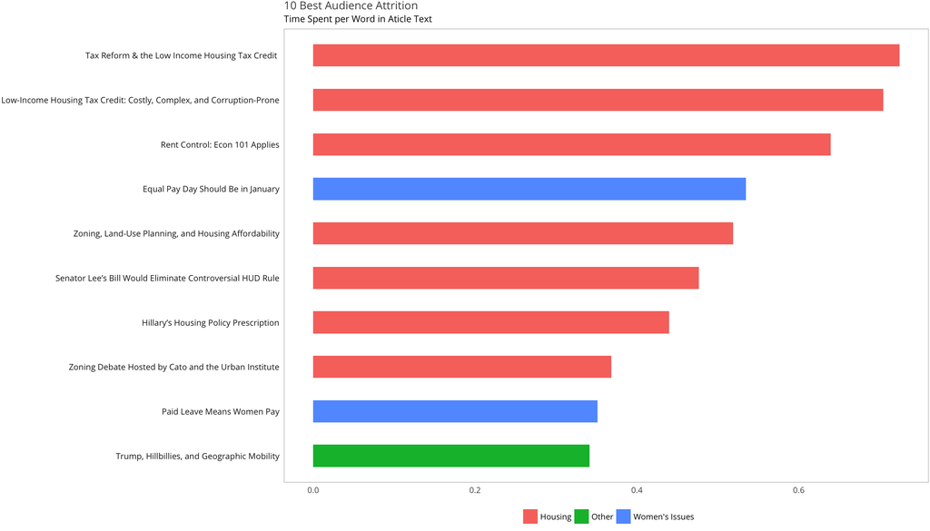

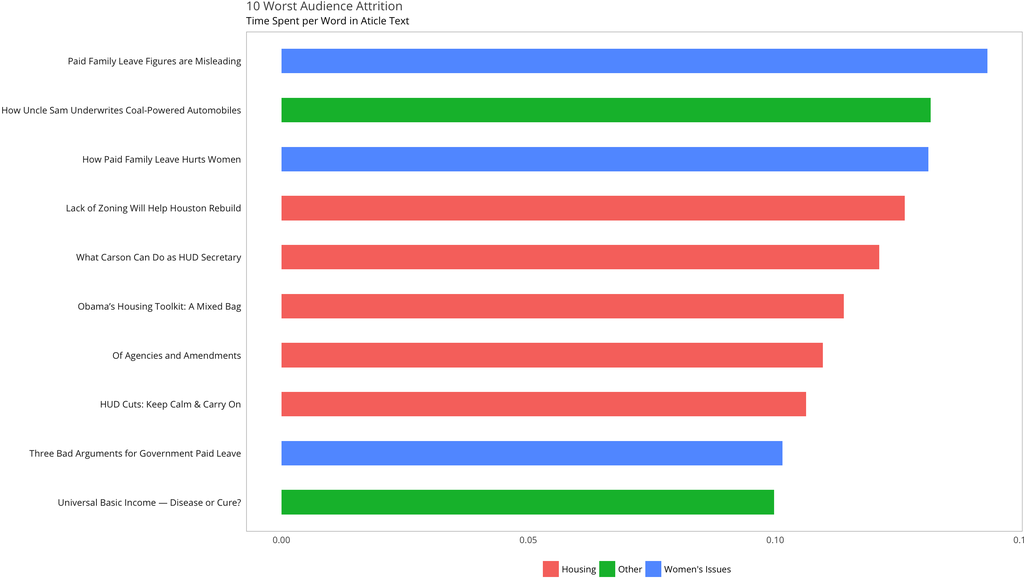

More to come on this…